# Primeros pasos con R y RStudio

## 0-Preparativos

.

En estas práctica vamos a introducir el programa estadístico R y RStudio. Este programa es gratuito y se pueden encontrar versiones para Windows, OSX y Linux en la página:

https://cran.r-project.org/

Aunque se puede trabajar directamete con R, utilizaremos un entorno llamado RStudio que facilita algunas tareas. Podemos descargar RStudio de https://www.rstudio.com/products/rstudio-desktop/

En la primera práctica de R veremos como crear un proyecto, introducir diferentes tipos de datos, modificar datos ya introducidos, calcular los estadísticos descriptivos de centralización, dispersión, posición y forma vistos en clase así como realizar distintos gráficos.

Descargamos de ADI el archivo *datosR.rar* y guardamos la carpeta resultante ‘datosR’ en el directorio principal de nuestro disco virtual o en cualquier sitio de nuestro portatil. Como veremos es muy importante distinguir mayúsculas de minúsculas.

Para abrir Rstudio hacemos doble clic sobre su icono.

### Proyectos

En primer lugar vamos a crear un projecto de R que estará alojado en `datosR`. En el menú de R studio *File* seleccionamos *New Project* y allí *existing directory* para después seleccionar la carpeta `datosR` que hemos creado. Una vez creado un proyecto, podremos arrancar Rstudio directamente desde el proyecto haciendo doble click sobre el icono del proyecto (en este caso con nombre *datosR.Rproj*)

Para comprobar cual es nuestro directorio de trabajo actual podemos escribir en la consola:

```r
getwd()
```

```
## [1] "U:/datosR"
```

Obteniendo la carpeta del proyecto.

Antes de empezar notar que podemos usar R como una calculadora. Vamos a probar:

```r
2+2
```

```
## [1] 4
```

En general trabajaremos no desde la consola sino desde un guión o script. Para crear un script basta con ir al menú File -> new file -> R script. Podemos guardar el script con el nombre *cursoR.R* allí iremos escribiendo los comandos del resto del guión, que podremos ejecutar de uno en uno o por bloques.

## 1. Edición de datos

Si tenemos un conjunto de datos y queremos introducirlos en R hay diversas posibilidades. Cada tipo de datos tendrá una manera especial de introducir los datos.

### 1.1 Datos numéricos.

Suponer que los datos 64, 79, 69, 77, 91 representan el peso en kg de 5 personas y queremos acumularlos en una variable numérica que se llame peso. Escribiremos lo siguiente:

```r
peso5 = c(64, 79, 69, 77, 91)
peso5
```

```
## [1] 64 79 69 77 91
```

Hemos utilizado el operador concatenación `c()`. Hay que tener cuidado con la sintaxis que es muy estricta (al igual que ocurría con maple).

Vamos ahora a introducir la altura de cinco personas en metros

```r
altura5 = c(1.55, 1.78, 1.67, 1.78, 1.93)
```

Para introducir datos consecutivos podemos usar el operador “`:`” así

```r
indices5 = 1:5
```

es lo mismo que

```r
indices5 = c(1,2,3,4,5)
```

### 1.2 Datos cualitativos (cadenas de caracteres). Factores

En general para trabajar con datos cualitativos en R, tendremos que definir las variables de tipo factor que contienen además de los datos, las distintas modalidades o niveles que estas pueden tomar.

Ahora queremos introducir el sexo de estas cinco personas. Tenemos los datos *mujer, hombre, mujer, hombre, hombre*. Para que el valor de una variable sea texto (cadena de caracteres) hay que escribirlo entre comillas. Así podríamos introducir los datos anteriores como:

```r
sexo5 = c("mujer", "hombre", "mujer", "hombre", "hombre")
sexo5
```

```
## [1] "mujer"  "hombre" "mujer"  "hombre" "hombre"
```

podemos transformar esta variable en una variable de tipo factor con:

```r
sexo5 = as.factor(sexo5)
sexo5
```

```
## [1] mujer  hombre mujer  hombre hombre
## Levels: hombre mujer
```

Notar como ademas de los valores de la variable me vienen especificados las modalidades o niveles `levels`.

Otra manera mas segura de obtener los resultados es especificar nosotros los niveles. Esto nos asegura que estén todos los niveles que interesan y en el orden adecuado (caso de que el orden importe)

```r
sexo5 = factor(sexo5, levels=c("hombre", "mujer"))
sexo5
```

```
## [1] mujer  hombre mujer  hombre hombre
## Levels: hombre mujer
```

De cualquier forma al introducir las variables a mano, es molesto tener que escribir tanto texto. Especialmente si en lugar de 5 datos tenemos muchos más.

Una forma de solucionar este problema es utilizar un “codigo numérico” para los distintos niveles (modalidades) de las variables cualitativas `levels` y asignar etiquetas `labels` a los niveles. Veamos un ejemplo

El grupo sanguíneo es un factor con 4 niveles. Por ejemplo queremos codificar el grupo sanguíneo con números de 1 a 4 donde 1 es A, 2 es B, 3 es AB y 4 es O. Ahora si mis cinco datos tienen grupo sanguíneo *A, B, A ,A, O*, puedo introducirlos usando los niveles antes descritos con las siguientes ordenes.

```r
gruposang5 = c(1, 2, 1, 1, 4)
gruposang5 = factor(gruposang5,
                    levels=1:4,
                    labels=c("A","B","AB","O"))
```

En resumen, para trabajar con variables cualitativas en R, es conveniente declararla como un factor que tendrá:

- *datos* numéricos o caracteres. En el ejemplo anterior los que había en gruposang5
- *niveles* (`levels`) pueden ser numeros o cadenas de caracteres en este caso: 1,2,3 y 4
- *etiquetas* (`labels`) siempre cadenas de caracteres, en este ejemplo *A*, *B*, *AB*, *O*.

Cuando los niveles sean ya cadenas de caracteres no hará falta especificar las etiquetas.

#### Cualitativas Ordinales

Podemos especificar que los niveles están ordenados en un factor que represente una variable ordinal. Imaginar que tenemos una variable que nos dice como se encuentran fisicamente las personas entre bien regular y mal.

```r
estfis5=c("bien","bien","mal","regular", "regular")
```

Podemos definir un factor ordenado mediante:

```r
estfis5=factor(estfis5,
               levels=c("bien", "regular", "mal"),
               ordered= TRUE)
estfis5
```

```
## [1] bien    bien    mal     regular regular
## Levels: bien < regular < mal
```

Vemos como ahora los niveles aparecen ordenados.

### 1.3 Data frames

```r
datos5=data.frame(peso5, altura5, sexo5, gruposang5, estfis5)
datos5
```

```
##   peso5 altura5  sexo5 gruposang5 estfis5
## 1    64    1.55  mujer          A    bien
## 2    79    1.78 hombre          B    bien
## 3    69    1.67  mujer          A     mal
## 4    77    1.78 hombre          A regular
## 5    91    1.93 hombre          O regular
```

Observar que en la primera columna aparece un número que simplemente va contando el número de individuos que tiene mi muestra.

La orden `str(objeto)` nos da información sobre un objeto de R. Es especialmente útil para saber lo que hay dentro de un data.frame

```r
str(datos5)
```

```
## 'data.frame':    5 obs. of  5 variables:
##  $ peso5     : num  64 79 69 77 91
##  $ altura5   : num  1.55 1.78 1.67 1.78 1.93
##  $ sexo5     : Factor w/ 2 levels "hombre","mujer": 2 1 2 1 1
##  $ gruposang5: Factor w/ 4 levels "A","B","AB","O": 1 2 1 1 4
##  $ estfis5   : Ord.factor w/ 3 levels "bien"<"regular"<..: 1 1 3 2 2
```

Si tenemos un data frame y queremos usar una de las variables que contiene escribiremos nombredataframe$nombre variable. Por ejemplo:

```r
datos5$altura5
```

```
## [1] 1.55 1.78 1.67 1.78 1.93
```

#### Guardando y leyendo como ficheros de texto.

Para guardar datos almacenados en un data frame podemos hacerlo con la orden:

```r
write.table(datos5, file= "datos5.txt")
```

Podemos usar `read.table` para leer un data frame que hayamos guardado con el comando `write.table`

```r
datos5bis = read.table("datos5.txt", header=T)
datos5bis
```

```
##   peso5 altura5  sexo5 gruposang5 estfis5
## 1    64    1.55  mujer          A    bien
## 2    79    1.78 hombre          B    bien
## 3    69    1.67  mujer          A     mal
## 4    77    1.78 hombre          A regular
## 5    91    1.93 hombre          O regular
```

```r
str(datos5bis)
```

```
## 'data.frame':    5 obs. of  5 variables:
##  $ peso5     : int  64 79 69 77 91
##  $ altura5   : num  1.55 1.78 1.67 1.78 1.93
##  $ sexo5     : Factor w/ 2 levels "hombre","mujer": 2 1 2 1 1
##  $ gruposang5: Factor w/ 3 levels "A","B","O": 1 2 1 1 3
##  $ estfis5   : Factor w/ 3 levels "bien","mal","regular": 1 1 2 3 3
```

Por defecto nos ha tomado las columnas de caracteres como factores pero hemos perdido el orden.

### 1.4 Importar datos desde otros programas

Introducir un data frame así puede resultar un poco pesado, pero es fácil importar datos a R desde cualquier editor de texto sin formatos, desde Excel desde otros programas de estadística como SPSS, STATA o SAS y lo que aún es más útil cuando se manejan muchos datos, R se comunica muy bien con bases de datos como Acess o mySQL .

#### Archivos de texto

Recordad que es fácil es importar datos desde un fichero de texto (.txt) donde tenemos los datos en columnas y como encabezamiento de cada columna el nombre de la variable correspondiente. Esto ocurrirá cuando hayamos guardado con `write.table()`

#### Archivos .csv

Un archivo .csv es un documento donde cada fila tiene el mismo número de datos separados por comas o puntos y comas.

En los archivos de programas en inglés los campos vienen separados por comas y los decimales por puntos. Si en la primera fila vienen los nombres de las variables debemos incluir `header=TRUE` Así importaremos archivos de este tipo con la orden

```r
misdatos = read.csv("myfile.csv",
                    header=TRUE, sep=",", dec=".")
```

Notar que para evitar escribir una línea muy larga hemos el comando en dos líneas. Es importante que el lugar que escogamos para partir la línea sea una coma como en el ejemplo anterior.

Cuando exportamos a csv desde programas en castellano (como excel) los decimales apareceran con comas y para evitar ambiguedades separarán los campos con punto y coma. Así importaremos archivos de este tipo con la orden

```r
misdatos=read.csv("mifichero.csv",
                  header=TRUE, sep=";", dec=",")
```

Una manera rápida de importar datos es seleccionar las casillas que nos interesen, dar a copiar y después en R usar.

```r
datos=read.delim("clipboard",
                 header=TRUE, dec=",", check.names=T)
```

Pero solo lo recomendamos para hacer alguna prueba rápida ya que no es reproducible (no queda constancia de lo que hemos seleccionado).

#### Importar archivos de excel

Para importar un data frame desde Excel nuestra hoja de cálculo ha de tener los datos de cada variable en una columna, con los nombres de la variable en la primera fila y los datos en las siguentes.

Hemos de guardar el fichero Excel como un fichero csv ( en Archivo -> guardar como… y seleccionar en guardar como TIPO  
CSV( delimitado por comas) (*.csv)

Después habrá que leerlo con el formato adecuado entre los descritos arriba (en el caso de Excel en castellano, tenemos los decimales separados por comas y por tanto necesitamos las opciones `sep=";", dec=","`)

Tenemos un archivo excel llamado gimnasio.xlsx datos de peso altura y ejercicio. Los valores de ejercicio están codificados con 1 para Nunca, 2 para Ocasional y 3 para Frecuente.

Una vez guardado como csv lo leemos con:

```r
gimnasio=read.csv("gimnasio.csv",
                  header=TRUE, sep=";",dec=",")
```

También se puede leer directamente desde excel utilizando en Rstudio Import dataset dentro de la pestaña Environment.

Dos ordenes muy útiles para hacernos una idea de lo que hay en un dataframe que hemos creado son `head(nombredataframe)` y `tail(nombredataframe)` que nos da los primeros y últimos valores del dataframe respectivamente. Por ejemplo

```r
head(gimnasio)
```

```
##   peso altura ejercicio
## 1   64   1.82         1
## 2   78   1.70         2
## 3   83   1.87         3
## 4   66   1.56         1
## 5   98   1.80         1
## 6   63   1.73         3
```

Con cualquier objeto de R podemos usar `str(objeto)` que nos dice que tipo de objetos hay almacenados

```r
str(gimnasio)
```

```
## 'data.frame':    20 obs. of  3 variables:
##  $ peso     : int  64 78 83 66 98 63 88 78 76 67 ...
##  $ altura   : num  1.82 1.7 1.87 1.56 1.8 1.73 1.76 1.87 1.75 1.56 ...
##  $ ejercicio: int  1 2 3 1 1 3 2 1 1 1 ...
```

Vemos que hay que transformar la última columna en un factor ordenado.

```r
gimnasio$ejercicio=factor(gimnasio$ejercicio,levels=1:3,
          labels=c("Nunca", "Ocasional", "Frecuente"),
          ordered= TRUE)

str(gimnasio)
```

```
## 'data.frame':    20 obs. of  3 variables:
##  $ peso     : int  64 78 83 66 98 63 88 78 76 67 ...
##  $ altura   : num  1.82 1.7 1.87 1.56 1.8 1.73 1.76 1.87 1.75 1.56 ...
##  $ ejercicio: Ord.factor w/ 3 levels "Nunca"<"Ocasional"<..: 1 2 3 1 1 3 2 1 1 1 ...
```

Notar que no puedo acceder directamente a las variables de dentro del data frame. Por ejemplo para calcular la media de una variable se usa `mean(nombrevariable)`

```r
mean(peso)
```

```
## Error in mean(peso): objeto 'peso' no encontrado
```

Da un error. En general usaremos `nombredataframe$nombrevariable` para acceder a una variable dentro de un dataframe.

```r
mean(gimnasio$peso)
```

```
## [1] 76.85
```

Otra manera de acceder dentro de un data frame es con la orden `with(nombredataframe, operacion)`

```r
with(gimnasio, mean(peso))
```

```
## [1] 76.85
```

## 2. Estadística descriptiva.

Veamos como obtener los distintos estadísticos descriptivos usando R.

### 2.1 Variables cuantitativas

Por ejemplo para los datos de peso de los datos del data frame gimnasio tenemos:

```r
mean(gimnasio$peso)
```

```
## [1] 76.85
```

```r
median(gimnasio$peso)
```

```
## [1] 77
```

```r
sd(gimnasio$peso)
```

```
## [1] 13.49181
```

```r
var(gimnasio$peso)
```

```
## [1] 182.0289
```

Nos dan la media, mediana, desviación típica y varianza respectivamente. Para obtener los cuartiles, o en general cualquier percentil podemos usar la orden `quantile(variable, probs=c(percentiles))`

```r
quantile(gimnasio$peso)
```

```
##    0%   25%   50%   75%  100%
## 53.00 66.75 77.00 86.50 99.00
```

```r
quantile(gimnasio$peso,probs=c(0.05, 0.95))
```

```
##    5%   95%
## 56.80 98.05
```

Podemos obtener un resumen (datos mayor y menor, cuartiles mediana y media para variables cuantitativas o una tabla de frecuencias parar variables cualitativas) con

```r
summary(gimnasio$peso)
```

```
##    Min. 1st Qu.  Median    Mean 3rd Qu.    Max.
##   53.00   66.75   77.00   76.85   86.50   99.00
```

Veamos algunos gráficos útiles para variables cuantitativas:

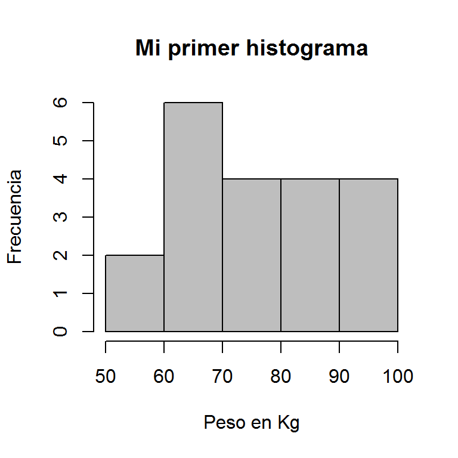

```r
hist (gimnasio$peso,
      main="Mi primer histograma",
      xlab="Peso en Kg", ylab="Frecuencia", col="grey")
```

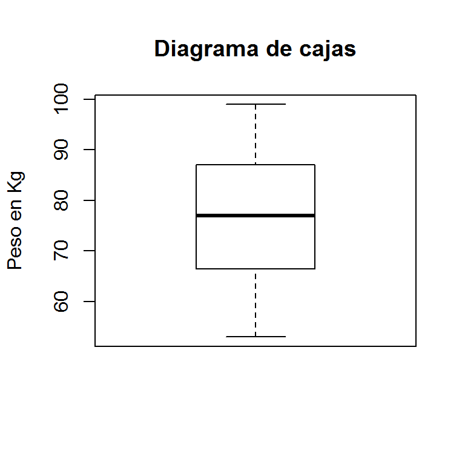

```r
boxplot (gimnasio$peso,
         main="Diagrama de cajas", ylab="Peso en Kg")
```

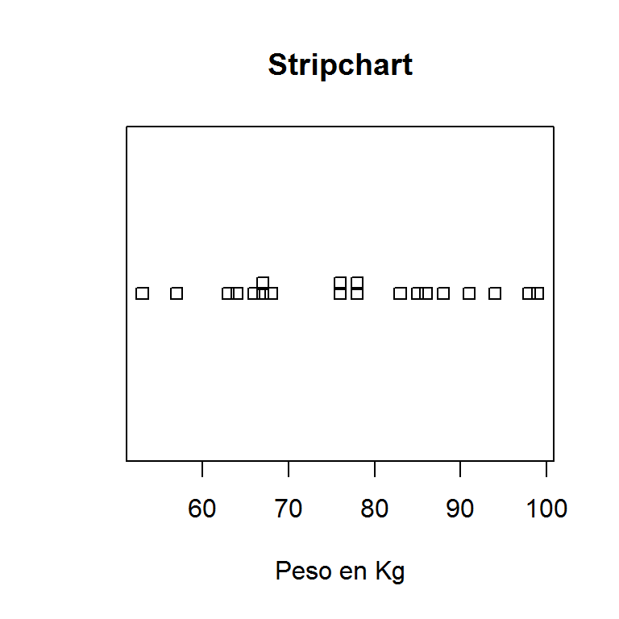

```r
stripchart(gimnasio$peso,
           main="Stripchart", method="stack", xlab="Peso en Kg")
```

Podemos añadir los datos a un histograma con:

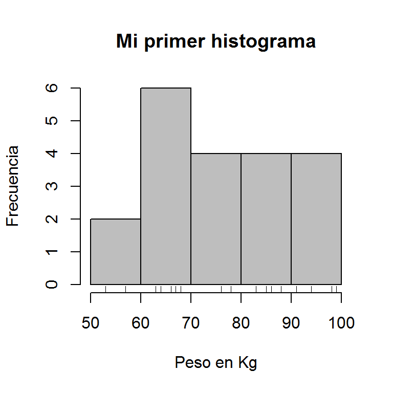

```r
hist (gimnasio$peso,
      main="Mi primer histograma",
      xlab="Peso en Kg", ylab="Frecuencia", col="grey")
rug(gimnasio$peso)
```

y a un boxplot con:

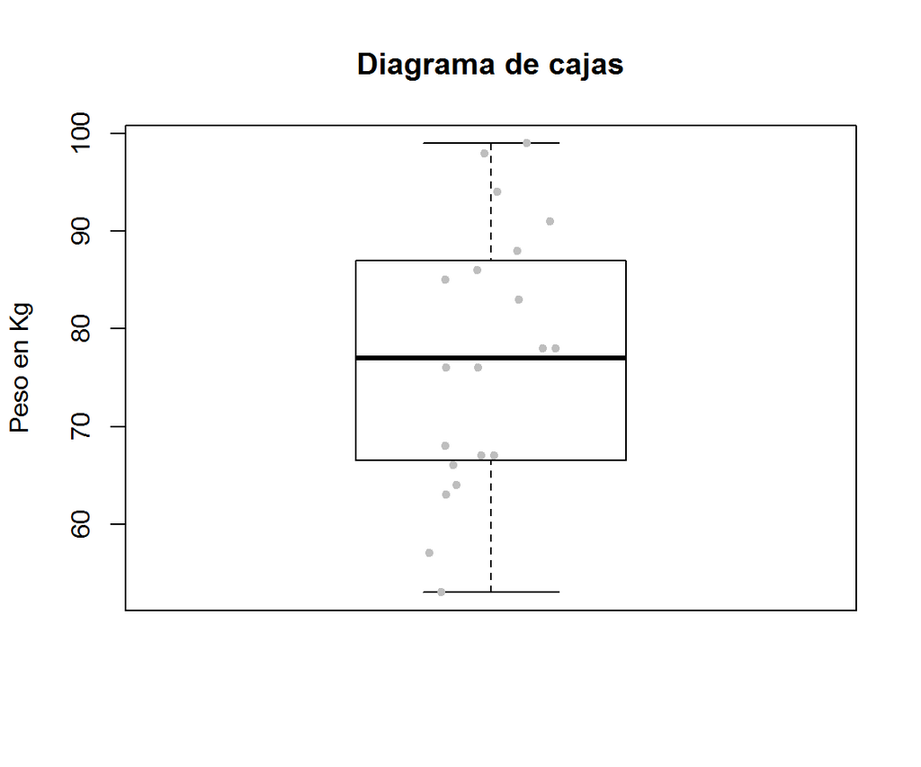

```r
boxplot (gimnasio$peso,
         main="Diagrama de cajas", ylab="Peso en Kg")
stripchart(gimnasio$peso,
           method="jitter",vertical=TRUE, pch=20, col="grey",
           add=TRUE)
```

### 2.2 Variables Cualitativas

Para variables cualitativas no tiene sentido hacer los estadísticos anteriores ni los gráficos.

Podemos hacer una tabla de frecuencias con la orden table

```r
table(gimnasio$ejercicio)
```

```
##
##     Nunca Ocasional Frecuente
##        10         4         6
```

```r
# para obtener frecuencias relativas dividimos por el número de datos.
#lo obtendremos con la orden nrow(dataframe) o length(vector)
table(gimnasio$ejercicio)/nrow(gimnasio)
```

```
##
##     Nunca Ocasional Frecuente
##       0.5       0.2       0.3
```

```r
summary(gimnasio$ejercicio)
```

```
##     Nunca Ocasional Frecuente
##        10         4         6
```

Ahora podemos hacer gráficos usando esa tabla de frecuencias. Por ejemplo:

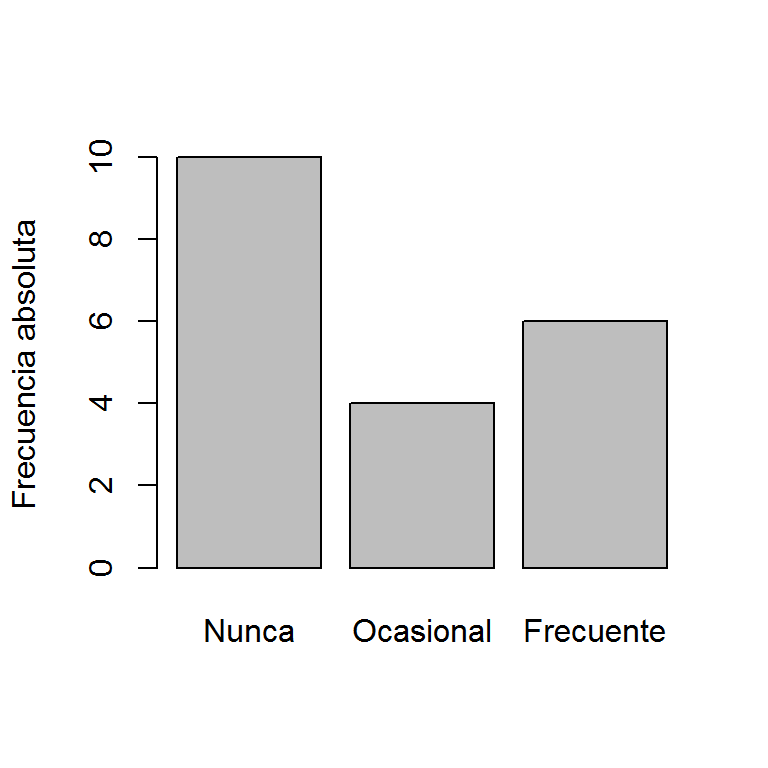

```r
barplot(table(gimnasio$ejercicio),ylab="Frecuencia absoluta")
```

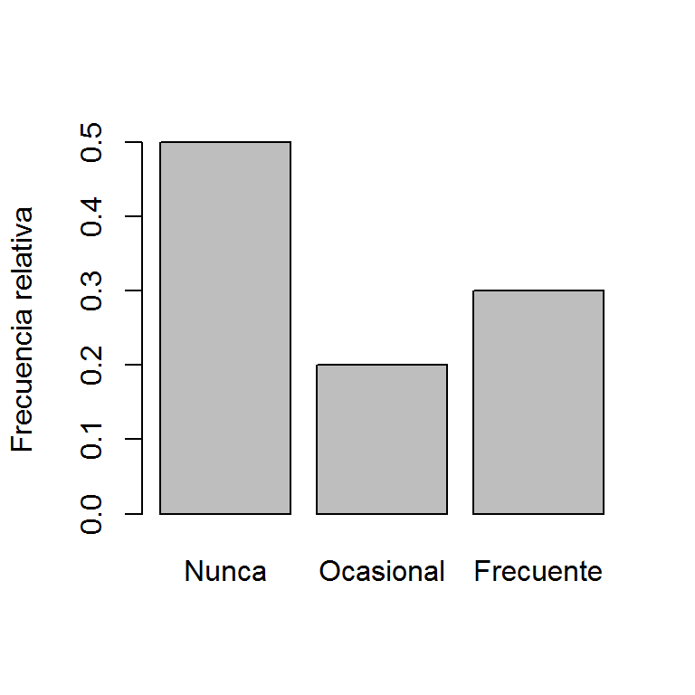

```r
barplot(table(gimnasio$ejercicio)/nrow(gimnasio),
        ylab="Frecuencia relativa")
```

Nos da un diagrama de barras. Notar que este diagrama da más información que el popular diagrama de sectores (o de quesitos) que podemos obtener con:

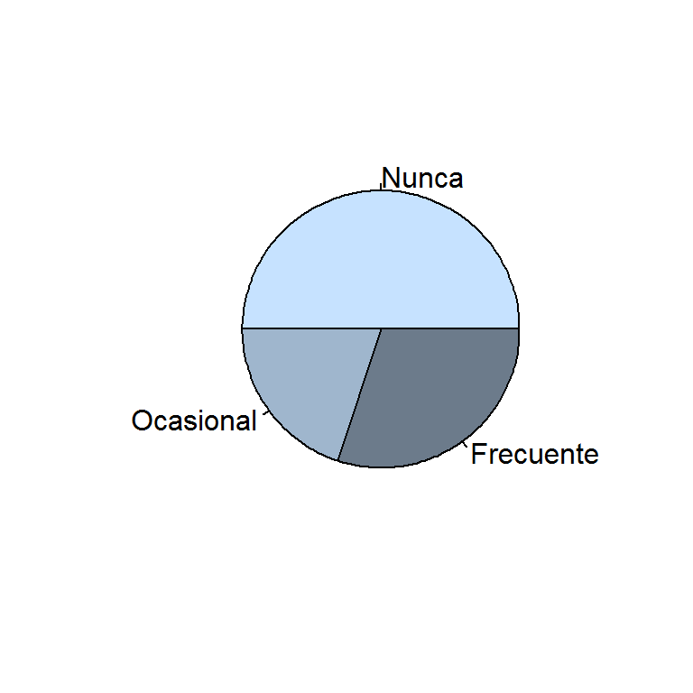

```r
pie(table(gimnasio$ejercicio),
    col=c("slategray1", "slategray3", "slategray4"))
```

Una situación cuando un diagrama de sectores puede dar información visual más rápida es cuando el total de los individuos que estoy describiendo juega un papel importante porque estoy repartiendo o distribuyendo algo. Por ejemplo en unas elecciones se reparten los escaños y un diagrama de sectores puede dar una información visual rápida sobre que coaliciones entre partidos consiguen la mayoría.

## 3 Intervalos de confianza y tests de hipótesis.

Veremos los procedimientos para calcular intervalos de confianza para una y dos medias usando r. En ambos casos usaremos la orden `t.test`

### 3.1 Estimación de una media.

R nos permite estimar mediante intervalo de confianza, la media de una población a partir de los datos de una muestra.

La estimación de la media la realizamos con:

```
t.test(nombredatos, mu=mediacontraste, conf.level=niveldeconfianza)
```

Ejemplo: Queremos comprobar si es cierto que la ingesta diaria energética en KJ para 11 mujeres con una determinada dieta se desvía significativamente de la cantidad recomendada de 7725 KJ.

La variable aleatoria que estudiamos es *ingesta diaria energética en KJ para mujeres con una determinada dieta*.

```r
ingesta=c(5260,5470,5640,6180,6390,6515,6805,7515,7515,8230,8770)
t.test(ingesta, mu=7725,conf.level=0.95)
```

```
##
##  One Sample t-test
##
## data:  ingesta
## t = -2.8208, df = 10, p-value = 0.01814
## alternative hypothesis: true mean is not equal to 7725
## 95 percent confidence interval:
##  5986.348 7520.925
## sample estimates:
## mean of x
##  6753.636
```

Con un 95 % de confianza podemos afirmar que la media de la ingesta diaria energética en KJ para mujeres con esta dieta está entre 5986.348 kJ y 7520.925 KJ, y por tanto es inferior a la cantidad recomendada de 7725 KJ en al menos 204.075 KJ.

Si queremos extraer únicamente los datos del intervalo de confianza podemos hacer:

```r
t.test(ingesta, mu=7725,conf.level=0.95)$conf.int
```

```
## [1] 5986.348 7520.925
## attr(,"conf.level")
## [1] 0.95
```

`t.test` hace por defecto, además del intervalo de confianza, un test de dos colas. El *p-valor* aparece en `p.value`. Para especificar el número de colas podemos usar la opción `alternative=` que puede tomar los valores:

1. `"two.sided"` para un test de dos colas
2. `"less"` para un test de una cola a la izda
3. `"greater"`

Así si en el ejemplo anterior quisieramos hacer un test de una cola a la izquierda escribiríamos:

```r
t.test(ingesta, mu=7725,conf.level=0.95, alternative="less")
```

```
##
##  One Sample t-test
##
## data:  ingesta
## t = -2.8208, df = 10, p-value = 0.009069
## alternative hypothesis: true mean is less than 7725
## 95 percent confidence interval:
##      -Inf 7377.781
## sample estimates:
## mean of x
##  6753.636
```

Comparar el *p-valor* con el del ejemplo anterior.

#### 3.1.2 Método no paramétrico. Contraste de wilcoxon.

Podemos realizar el contraste de los rangos de Wilcoxon utilizando `wilcox.test()`

```r
wilcox.test(ingesta,mu=7725)
```

```
##
##  Wilcoxon signed rank test with continuity correction
##
## data:  ingesta
## V = 8, p-value = 0.0293
## alternative hypothesis: true location is not equal to 7725
```

### 3.2 Comparación de medias:

#### 3.2.1: Muestras independientes.

Ha habido una queja de que los medicos de cierta aseguradora pasa menos tiempo en media con los pacientes obesos. Tenemos los datos de una muestra en *tiempopeso.txt* donde la variable peso está codificada como *1=“no_obeso”*, *2 = “obeso”*. En primer lugar leemos los datos.

```r
datosAseguradora=read.table("tiempopeso.txt",header=TRUE)
```

La variable `Peso` no es un factor pero querríamos que lo fuese. Definimos Peso como un factor.

```r
datosAseguradora$Peso=factor(datosAseguradora$Peso,
                             levels=1:2,
                             labels=c("no_obeso", "obeso"))
str(datosAseguradora)
```

```
## 'data.frame':    71 obs. of  2 variables:
##  $ Peso  : Factor w/ 2 levels "no_obeso","obeso": 1 1 1 1 1 1 1 1 1 1 ...
##  $ Tiempo: int  15 15 45 40 45 20 40 30 40 30 ...
```

Comparamos los datos gráficamente con diagramas de cajas.

Nota: para conseguir la virgulilla `~` en Windows has de:

1. presionar la tecla `Alt`.
2. sin soltar `Alt` introducir el numero `126` en el teclado numérico.
3. soltar la tecla `Alt`.

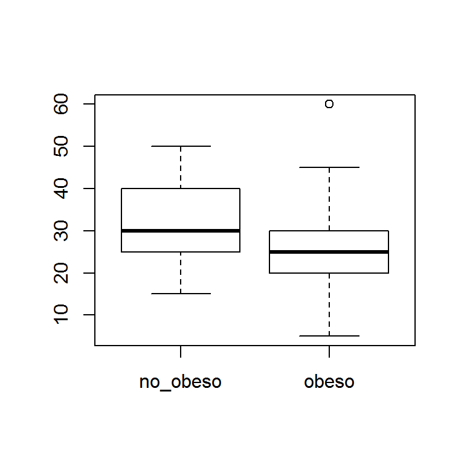

```r
boxplot(Tiempo~Peso, data=datosAseguradora)
```

¿Son las varianzas iguales?

```r
var.test(Tiempo~Peso, data=datosAseguradora)
```

```
##
##  F test to compare two variances
##
## data:  Tiempo by Peso
## F = 1.0443, num df = 32, denom df = 37, p-value = 0.8931
## alternative hypothesis: true ratio of variances is not equal to 1
## 95 percent confidence interval:
##  0.5333405 2.0797269
## sample estimates:
## ratio of variances
##           1.044316
```

En R la virgulilla `~`, se puede traducir como *según los valores de* por ejemplo, haz un boxplot de la variable Tiempo según los valores de la variable Peso.

Notar que no hemos necesitado escribir `datosAseguradora$Tiempo` y `datosaseguradora$Peso`. En las expresiones que usen la virgulilla, se puede especificar el data frame incluyendo la opción `data = nombredeldataframe`

El intervalo de confianza para el cociente de las varianzas nos muestra que este cociente puede valer uno y por tanto podemos considerar las variables iguales.

Ahora podemos calcular el intervalo de confianza para comparar las medias con:

```r
t.test(Tiempo~Peso,mu=0,conf.level=0.95, var.equal=TRUE, data=datosAseguradora)
```

```
##
##  Two Sample t-test
##
## data:  Tiempo by Peso
## t = 2.856, df = 69, p-value = 0.005663
## alternative hypothesis: true difference in means is not equal to 0
## 95 percent confidence interval:
##   1.997955 11.255633
## sample estimates:
## mean in group no_obeso    mean in group obeso
##               31.36364               24.73684
```

Notar que por defecto R hace el test de Welch para varianzas distintas (si no ponemos nada va a tomar `var.equal=FALSE`).

#### 3.2.2 Muestras no emparejadas. Alternativa no paramétrica. Contraste de la suma de rangos de Wilcoxon (equiv U de Mann-Whitney)

La alternativa no paramétrica a un test de hipótesis para muestras equivalentes es el contraste de la suma de rangos de wilcoxon que es equivalente al test U de Mann-Whitney. Ambos requieren que las muestras tengan varianzas parecidas.

```r
wilcox.test(Tiempo~Peso,conf.level=0.95, data=datosAseguradora)
```

```
##
##  Wilcoxon rank sum test with continuity correction
##
## data:  Tiempo by Peso
## W = 866, p-value = 0.003985
## alternative hypothesis: true location shift is not equal to 0
```

#### 3.2.3: Muestras emparejadas.

Estudiamos el numero de accidentes de tráfico en 9 puntos negros antes y después de señalarlos como tales.

```r
accidentes=data.frame(Antes =   c(3,3,2,2,4,3,2,2,1),
                      Despues = c(3,2,1,1,2,1,1,1,2))
```

Para hacer un test de muestras emparejadas, puedo o bien crear una nueva variable y aplicar un test de una sola variable.

```r
Diferencia=accidentes$Antes-accidentes$Despues
t.test(Diferencia, mu=0, conf.level=0.95)
```

[output not shown]

O directamente con la opción `paired=TRUE`.

```r
with(accidentes,
     t.test(Antes,Despues, paired=TRUE, conf.level=0.95))
```

```
##
##  Paired t-test
##
## data:  Antes and Despues
## t = 2.8737, df = 8, p-value = 0.02071
## alternative hypothesis: true difference in means is not equal to 0
## 95 percent confidence interval:
##  0.1755951 1.6021826
## sample estimates:
## mean of the differences
##               0.8888889
```

Se puede hacer calculando la muestra de las diferencias y después un test de Wilcoxon para una muestra o directamente con:

```r
with(accidentes,
     wilcox.test(Antes,Despues, paired=TRUE, conf.level=0.95))
```

```
##
##  Wilcoxon signed rank test with continuity correction
##
## data:  Antes and Despues
## V = 32.5, p-value = 0.04007
## alternative hypothesis: true location shift is not equal to 0
```

## 4 Regresión y Correlación.

### 4.1 Regresión lineal simple

El ejemplo que vamos a ver estudia como varía la tasa de crecimiento de unas plantas (en mm/semana) con respecto a la humedad del suelo. Los datos están en un archivo llamado `plant.growth.rate.csv`

**Ejercicio:** Leer el archivo `plant.growth.rate.csv` en un data frame que llamaremos Estudio_Crecimiento

En primer lugar vamos a cambiar los nombres de la variable a `humedad_suelo` y `tasa_crecimiento`

```r
names(Estudio_Crecimiento) <- c("humedad_suelo", "tasa_crecimiento")
```

#### Diagrama de dispersión

Ahora dibujaremos una nube de puntos para ver si podemos apreciar una tendencia lineal.

Es importante el orden de las variables: `tasa_crecimiento ~ humedad_suelo` se entiende como *tasa de crecimiento en funcion de la humedad del suelo* donde `humedad_suelo` aparece en el eje X (variable independiente) y `tasa_crecimiento` en el eje Y (variable dependiente) En este caso:

```r
plot(tasa_crecimiento ~ humedad_suelo, data = Estudio_Crecimiento)
```

[output not shown]

#### Correlación

Para calcular el coeficiente de correlación de Pearson de dos variables `x` e `y` usaremos `cor(x,y)`. Como estamos trabajando con un data frame utilizaremos la orden with

```r
with(Estudio_Crecimiento, cor(humedad_suelo, tasa_crecimiento) )
```

```
## [1] 0.8745262
```

Nos da una correlacion buena.

#### Recta de regresión

Para calcular los coeficientes de la recta de regresión de la tasa de crecimiento en funcion de la humedad del suelo (cuidado con el orden de las variables) basta con hacer:

```r
recta=lm(tasa_crecimiento ~ humedad_suelo, data = Estudio_Crecimiento)
```

Podemos dibujar el gráfico anterior con la recta incluida.

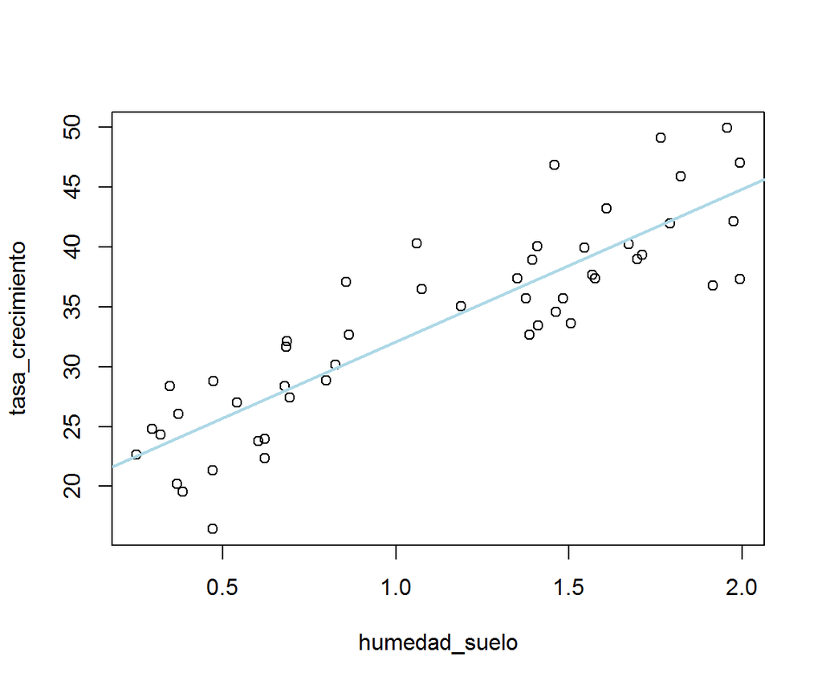

```r
plot(tasa_crecimiento ~ humedad_suelo, data = Estudio_Crecimiento)
recta=lm(tasa_crecimiento ~ humedad_suelo, data = Estudio_Crecimiento)
abline(recta, col="lightblue", lwd=2)
```

Ahora exploramos que hay en recta:

```r
recta
```

```
##
## Call:
## lm(formula = tasa_crecimiento ~ humedad_suelo, data = Estudio_Crecimiento)
##
## Coefficients:
##   (Intercept)  humedad_suelo
##         19.35          12.75
```

La recta de regresión obtenida (redondeando) es $\mu_{Y|x} = 19.348 + 12.75 \cdot x$, donde $x$ es la variable predictora (humedad del suelo) e $y$ es la variable dependiente (tasa de crecimiento) que queremos predecir. Con ella podemos estimar valores desconocidos que estén en el rango de los datos obtenidos (en nuestro caso valores de humedad del suelo entre 0.25 y 2). Por ejemplo para un valor de humedad del suelo de 1 obtenemos una estimación para la tasa de crecimiento de $19.348 + 12.75 \cdot 1 = 32.098$ mm/semana.

Podemos obtener valores de predicción con la orden `predict` (cuidado con la sintaxis)

```r
predict(recta, newdata = data.frame(humedad_suelo = 1))
```

```
##      1
## 32.098
```

Notar que no podemos extrapolar los datos más allá del rango de la muestra.

Podemos tener más información sobre los coeficientes con:

```r
summary(recta)
```

```
##
## Call:
## lm(formula = tasa_crecimiento ~ humedad_suelo, data = Estudio_Crecimiento)
##
## Residuals:
##     Min      1Q  Median      3Q     Max
## -8.9089 -3.0747  0.2261  2.6567  8.9406
##
## Coefficients:
##               Estimate Std. Error t value Pr(>|t|)
## (Intercept)     19.348      1.283   15.08   <2e-16 ***
## humedad_suelo   12.750      1.021   12.49   <2e-16 ***
## ---
## Signif. codes:  0 '***' 0.001 '**' 0.01 '*' 0.05 '.' 0.1 ' ' 1
##
## Residual standard error: 4.019 on 48 degrees of freedom
## Multiple R-squared:  0.7648, Adjusted R-squared:  0.7599
## F-statistic: 156.1 on 1 and 48 DF,  p-value: < 2.2e-16
```

Podemos obtener los intervalos de confianza de los coeficientes con la orden `confint`

```r
confint(recta)
```

```
##                  2.5 %   97.5 %
## (Intercept)   16.76833 21.92859
## humedad_suelo 10.69764 14.80144
```

```r
recta=lm(tasa_crecimiento ~ humedad_suelo, data = Estudio_Crecimiento)

datosaux= with(Estudio_Crecimiento,
               seq(min(humedad_suelo),max(humedad_suelo),len=100))

conf_interval <- predict(recta,
               newdata=data.frame(humedad_suelo = datosaux),
               interval="confidence",level= 0.95)


pred_interval <- predict(recta,
               newdata=data.frame(humedad_suelo = datosaux),
               interval="prediction",level = 0.95)
```

Ahora dibujamos la nube de puntos, la recta de regresión, las bandas de confianza e intervalos de predicción.

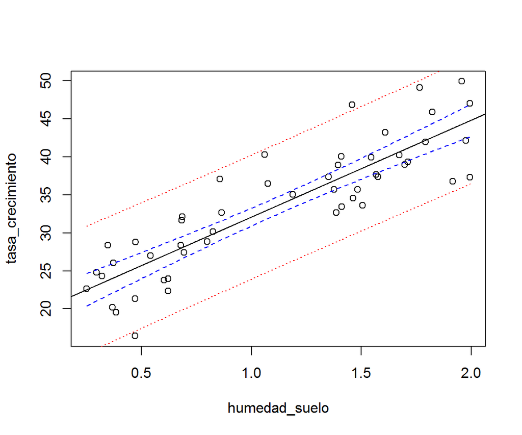

```r
plot(tasa_crecimiento ~ humedad_suelo, data = Estudio_Crecimiento)
abline(recta)

lines(datosaux, conf_interval[,2], col="blue", lty=2)
lines(datosaux, conf_interval[,3], col="blue", lty=2)

lines(datosaux, pred_interval[,2], col="red", lty=3)
lines(datosaux, pred_interval[,3], col="red", lty=3)
```

Se puede (y se debe) hacer mucho más para estudiar la bondad de nuestra recta para explicar los datos de la muestra: intervalos de confianza de los coeficientes, estudiar los residuos, por ejemplo podemos obtener unos diagnósticos para la regresión con:

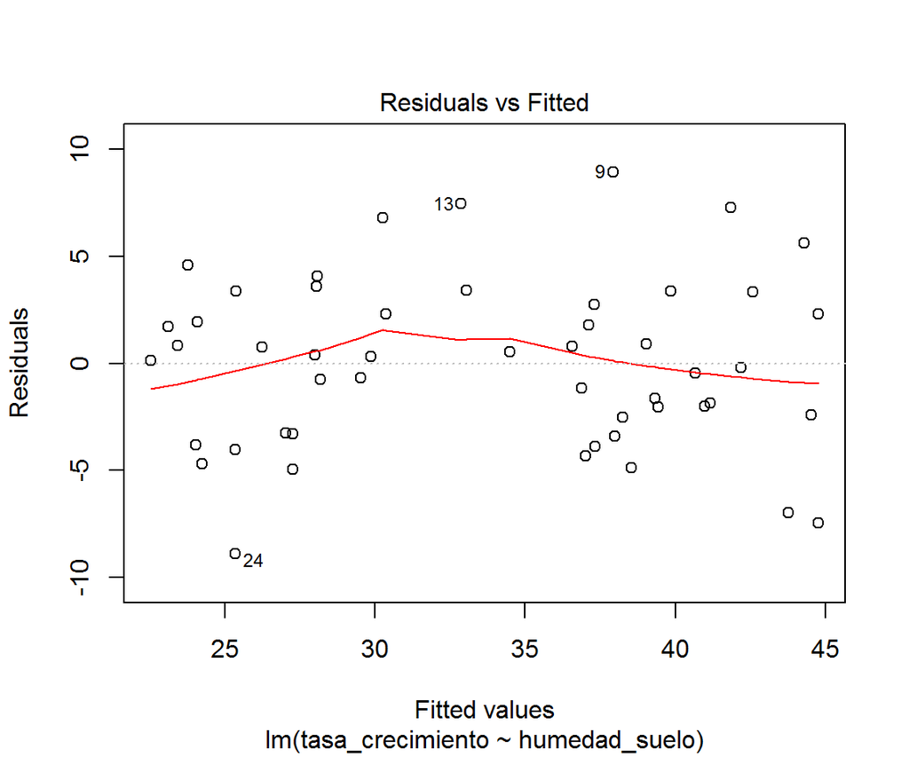

```r
plot(recta,1)
```

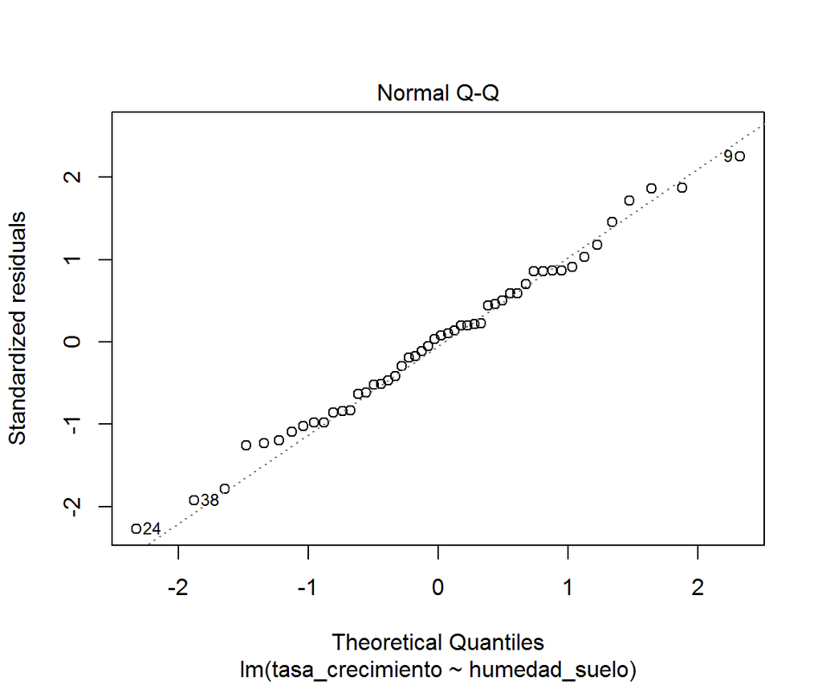

```r
plot(recta,2)
```

### 4.2 Regresión Cuadrática.

En algunas ocasiones se apreciará una tendencia entre nuestros datos que no será una recta: (Descargar de ADI *datcuad.txt*) Vemos una tendencia cuadrática clara en este ejemplo.

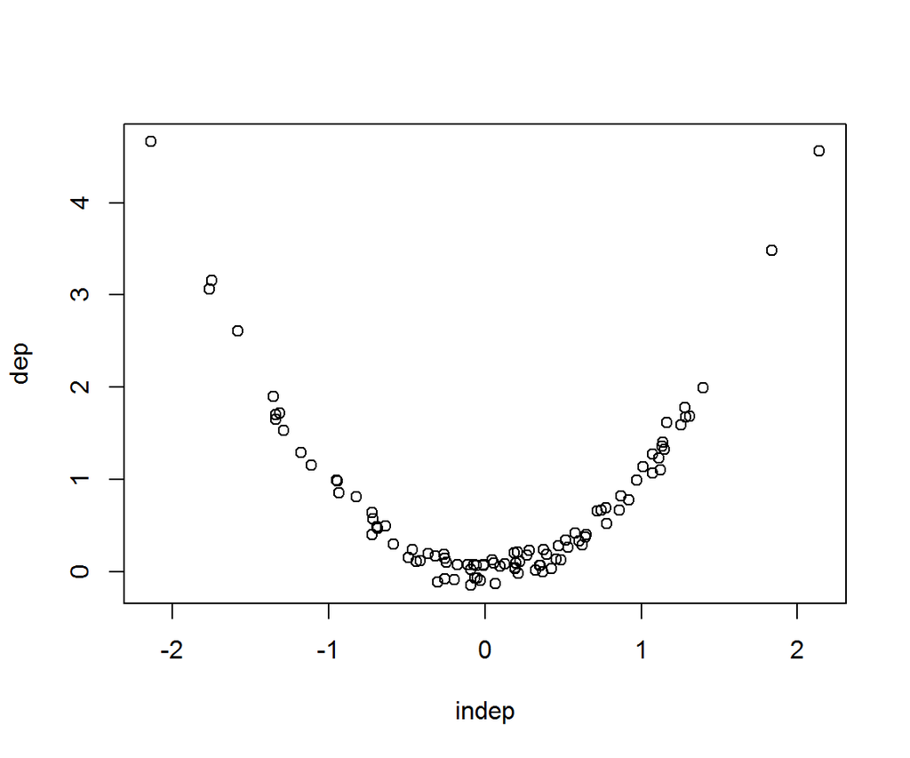

```r
datoscuadraticos=read.table("datcuad.txt")

plot(dep~indep,data=datoscuadraticos)
```

```r
parabola=lm(dep~indep + I(indep^2), data=datoscuadraticos)
parabola
```

```
##
## Call:
## lm(formula = dep ~ indep + I(indep^2), data = datoscuadraticos)
##
## Coefficients:
## (Intercept)        indep   I(indep^2)
##    0.001562     0.013416     1.009149
```

De donde obtenemos:

$\mu_{dep|indep} = 0.002 + 0.013 \cdot indep + 1.009 \cdot indep^2$

Podemos dibujar la nube de puntos y el ajuste con:

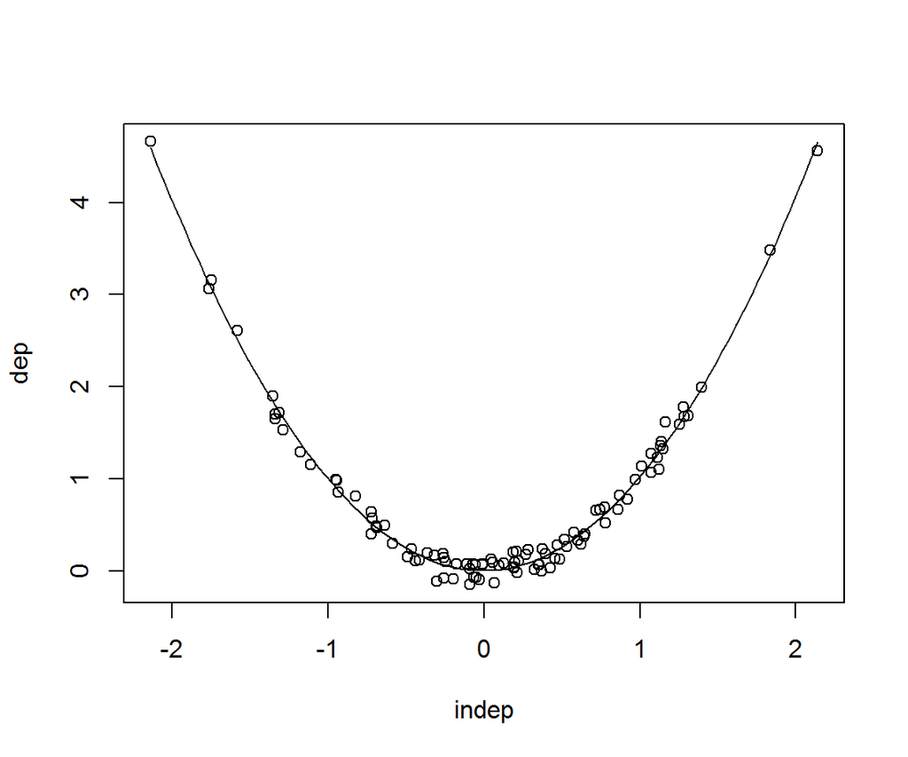

```r
plot(dep~indep, data=datoscuadraticos)
datosaux= seq(min(datoscuadraticos$indep),max(datoscuadraticos$indep),len=100)
lines(datosaux,predict(parabola,data.frame(indep=datosaux)))
```

Ahora podemos obtener el coeficiente de determinación $R^2$ con:

```r
summary(parabola)$r.squared
```

```
## [1] 0.990405
```

Obtenemos $R^2 =$ 0.990405. El 99% de la variabilidad de la variable dependiente viene explicada por la variabilidad en la variable independiente.

## 5. Estimación de proporciones

Veremos como estimar proporciones de datos categóricos con R.

### 5.1 Estimación de una proporción.

Suponemos que tiramos una moneda y obtenemos 900 caras de 1000 tiradas. Todo parece indicar que la moneda está trucada. Podemos confirmar estadísticamente esto, realizando un intervalo de confianza para la proporcion, y el correspondiente test de hipótesis (por defecto de dos colas.)

```r
prop.test(900,1000, conf.level=0.95)
```

```
##
##  1-sample proportions test with continuity correction
##
## data:  900 out of 1000, null probability 0.5
## X-squared = 638.4, df = 1, p-value < 2.2e-16
## alternative hypothesis: true p is not equal to 0.5
## 95 percent confidence interval:
##  0.8793091 0.9175476
## sample estimates:
##   p
## 0.9
```

Recordamos que este test se basa en aproximar una binomial por una normal. R puede calcular el test binomial exacto.

```r
binom.test(900,1000, conf.level=0.95)
```

```
##
##  Exact binomial test
##
## data:  900 and 1000
## number of successes = 900, number of trials = 1000, p-value <
## 2.2e-16
## alternative hypothesis: true probability of success is not equal to 0.5
## 95 percent confidence interval:
##  0.8797121 0.9178947
## sample estimates:
## probability of success
##                    0.9
```

Si tenemos una variable que sea un factor con dos modalidades podemos hacer directamente el test de proporciones sobre una tabla. Veamos un ejemplo: Entre los directivos de 145 empresas biotecnológicas hay 88 hombres y 57 mujeres. ¿Puede ser esta diferencia debida al azar? Supongamos que nos dan los datos en un vector llamado sexo, con 1 para hombre y 2 para mujer.

```r
sexo=factor(c(rep(1,88),rep(2,57)),levels=1:2, labels=c("hombre","mujer"))
table(sexo)
```

```
## sexo
## hombre  mujer
##     88     57
```

```r
prop.test(table(sexo),conf.level=0.95)
```

```
##
##  1-sample proportions test with continuity correction
##
## data:  table(sexo), null probability 0.5
## X-squared = 6.2069, df = 1, p-value = 0.01273
## alternative hypothesis: true p is not equal to 0.5
## 95 percent confidence interval:
##  0.5221451 0.6858942
## sample estimates:
##         p
## 0.6068966
```

Por defecto, si tenemos dos modalidades, R calcula un intervalo de confianza para la proporción de la primera modalidad, en este caso hombre.

### 5.2 Comparación de dos proporciones.

La asignatura de bioestadística se divide en dos grupos, uno en inglés y otro en castellano. En el grupo de inglés 14 alumnos de un total de 38 obtienen un sobresaliente, mientras que en el grupo en castellano, 10 alumnos de un total de 40 obtienen un sobresaliente. Vamos a realizar un test de hipótesis para la igualdad de proporciones. De nuevo tenemos una variable cualitativa con dos modalidades (sacar un sobresaliente o no.)

```r
exitos=c(14,10)
nalumnos=c(38,40)
prop.test(exitos,nalumnos, conf.level=0.95)
```

```
##
##  2-sample test for equality of proportions with continuity
##  correction
##
## data:  exitos out of nalumnos
## X-squared = 0.7872, df = 1, p-value = 0.3749
## alternative hypothesis: two.sided
## 95 percent confidence interval:
##  -0.1110245  0.3478666
## sample estimates:
##    prop 1    prop 2
## 0.3684211 0.2500000
```

Vemos que la diferencia observada en esta muestra no es significativa.

## 6 Tablas de Contingencia.

### 6.1 Prueba de independencia.

Realizamos una investigación sobre una nueva vacuna contra la gripe. Se elige una muestra aleatoria de 900 individuos y se clasifica a cada uno de ellos según haya contraído la gripe durante el último año o no, y según haya sido o no vacunado. Se recogen los datos descritos a continuación.

```r
gripe=c(rep(1,450),rep(2,450))
gripe=factor(gripe, levels=1:2,labels=c("Si","No"))
vacuna=(c(rep(1,150),rep(2,300),rep(1,200),rep(2,250)))
vacuna=factor(vacuna,levels=1:2,labels=c("Si","No"))
```

Realizamos ahora la estadística descriptiva para estos datos mediante una tabla de contingencia y un diagrama de mosaico.

```r
table(vacuna, gripe)
```

```
##       gripe
## vacuna  Si  No
##     Si 150 200
##     No 300 250
```

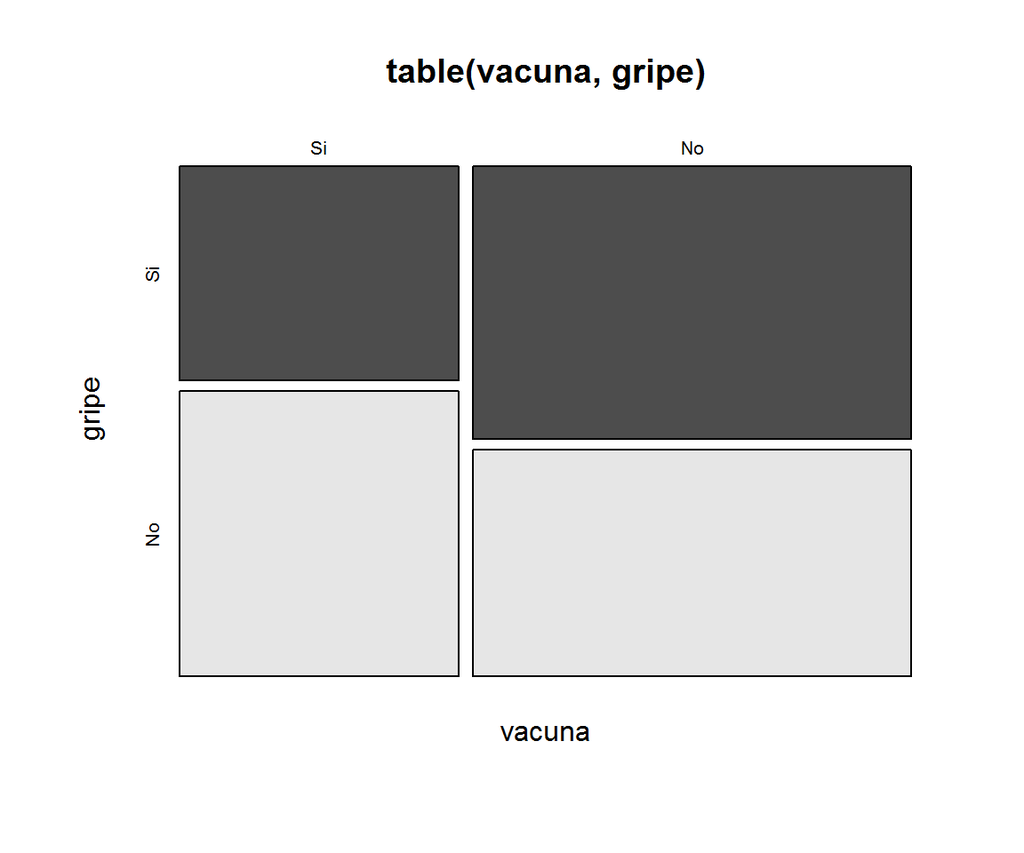

```r
mosaicplot(table(vacuna,gripe), color = TRUE)
```

La orden summary ejecuta ahora un test chi cuadrado de independencia.

```r
summary(table(vacuna, gripe))
```

```
## Number of cases in table: 900
## Number of factors: 2
## Test for independence of all factors:
##  Chisq = 11.688, df = 1, p-value = 0.0006289
```

También lo hace la orden `chisq.test(table(), correct=FALSE)`

```r
chisq.test(table(vacuna,gripe),correct=FALSE)
```

```
##
##  Pearson's Chi-squared test
##
## data:  table(vacuna, gripe)
## X-squared = 11.688, df = 1, p-value = 0.0006289
```

La opción incluye la corrección de continuidad de Yates para tablas 2x2. es un poco más conservadora

```r
chisq.test(table(vacuna,gripe),correct=TRUE)
```

```
##
##  Pearson's Chi-squared test with Yates' continuity correction
##
## data:  table(vacuna, gripe)
## X-squared = 11.225, df = 1, p-value = 0.0008068
```

Por último con R podemos hacer el test exacto de Fischer para tablas 2x2. Esto será especialmente útil cuando alguna de las casillas tenga menos de 5 individuos.

```r
fisher.test(table(vacuna,gripe))
```

```
##
##  Fisher's Exact Test for Count Data
##
## data:  table(vacuna, gripe)
## p-value = 0.0007957
## alternative hypothesis: true odds ratio is not equal to 1
## 95 percent confidence interval:
##  0.4725751 0.8263125
## sample estimates:
## odds ratio
##  0.6253451
```

### 6.2 Prueba de homogeneidad.

```r
mitabla=matrix(c(5,9,12,3,7,5),ncol=3)
colnames(mitabla)=c("frito","tortilla","cocido")
rownames(mitabla)=c("Mujer","Hombre")
mitabla
```

```
##        frito tortilla cocido
## Mujer      5       12      7
## Hombre     9        3      5
```

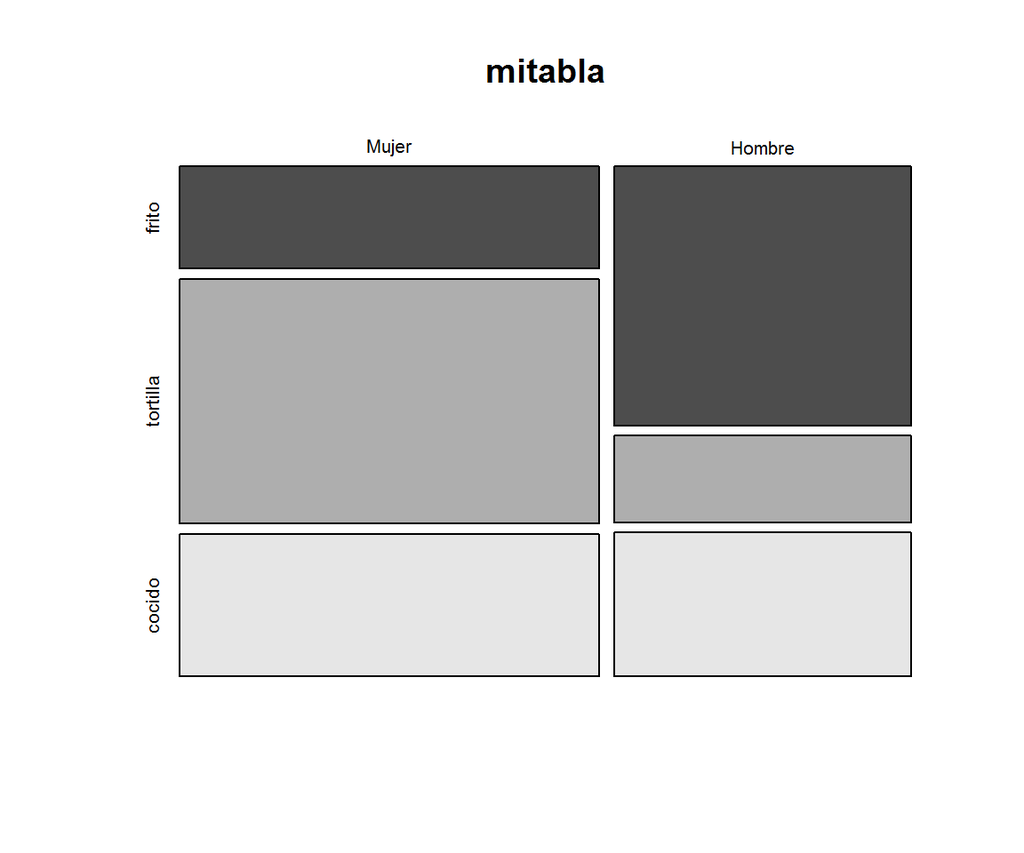

```r
mosaicplot(mitabla, color=TRUE)
```

Realizamos ahora el correspondiente test de homogeneidad

```r
chisq.test(mitabla)
```

```
## Warning in chisq.test(mitabla): Chi-squared approximation may be incorrect
```

```
##
##  Pearson's Chi-squared test
##
## data:  mitabla
## X-squared = 5.8516, df = 2, p-value = 0.05362
```

Nos damos cuenta que aparece una advertencia de que el test puede no ser adecuado. Esto es debido a que tenemos tres casos con 5 individuos o menos de un total de 6 (más del 20%). R nos permite utilizar un método de montecarlo para encontrar un p-value.

```r
chisq.test(mitabla,simulate.p.value = TRUE, B = 10000)
```

```
##
##  Pearson's Chi-squared test with simulated p-value (based on 10000
##  replicates)
##
## data:  mitabla
## X-squared = 5.8516, df = NA, p-value = 0.05739
```

## 7 Análisis de la varianza

### 7.1 Anova de una vía.

Vamos a usar unos datos presentes en R. Se trata de un estudio sobre 6 insecticidas. Se dividió un área geográfica homogénea en 72 zonas del mismo tamaño. Se seleccionaron 12 zonas al azar para el insecticida A, de las restantes 12 para el insecticida B, de las restantes 12 para el insecticida C, etc hasta tener una asignación aleatoria de 12 zonas para cada insecticida. Los datos están guardados en InsectSrays.

```r
data(InsectSprays)
str(InsectSprays)
```

```
## 'data.frame':    72 obs. of  2 variables:
##  $ count: num  10 7 20 14 14 12 10 23 17 20 ...
##  $ spray: Factor w/ 6 levels "A","B","C","D",..: 1 1 1 1 1 1 1 1 1 1 ...
```

```r
head(InsectSprays)
```

```
##   count spray
## 1    10     A
## 2     7     A
## 3    20     A
## 4    14     A
## 5    14     A
## 6    12     A
```

Vamos a realizar algunos estadísticos descriptivos por insecticida. Vamos a ver dos maneras de trabajar muy útiles en R. `with(dataframe,funcion(variables))` permite útilizar variables de un data frame sin necesidad de poner `dataframe$variable`, o usar `attach(dataframe)`.

Por otra parte utilizaremos `tapply(variable, grupo, funcion)` que aplica una funcion a una variable según los valores de grupo, una variable cualitativa.

Por ejemplo vamos a calcular la media, desviación estardar, y tamaño muestral de la variable `count` según el tipo de insecticida codificado en la variable `spray`:

```r
with(InsectSprays,tapply(count,spray,mean))
```

```
##         A         B         C         D         E         F
## 14.500000 15.333333  2.083333  4.916667  3.500000 16.666667
```

```r
with(InsectSprays,tapply(count,spray,sd))
```

```
##        A        B        C        D        E        F
## 4.719399 4.271115 1.975225 2.503028 1.732051 6.213378
```

```r
with(InsectSprays,tapply(count,spray,length))
```

```
##  A  B  C  D  E  F
## 12 12 12 12 12 12
```

Otra manera de hacerlo de modo más elegante es utilizar el paquete `dplyr` (habrá que instalarlo si procede.)

```r
library(dplyr)
InsectSprays %>%
  group_by(spray) %>%
  summarise(media=mean(count), desvest=sd(count), tamaño=length(count))
```

```
## # A tibble: 6 x 4
##   spray media desvest tamaño
##   <fct> <dbl>   <dbl>  <int>
## 1 A     14.5     4.72     12
## 2 B     15.3     4.27     12
## 3 C      2.08    1.98     12
## 4 D      4.92    2.50     12
## 5 E      3.5     1.73     12
## 6 F     16.7     6.21     12
```

Ahora dibujamos los correspondientes diagramas de caja. Vemos como boxplot nos permite una alternativa a `with(...)` usando `boxplot(...,data=InsectSprays)`. Hay muchas funciones en R que permiten especificar el dataframe como opción con `data=nombredataframe`. El resultado es el mismo que el que obtendríamos usando `with(InsectSprays,boxplot(count~spray))`

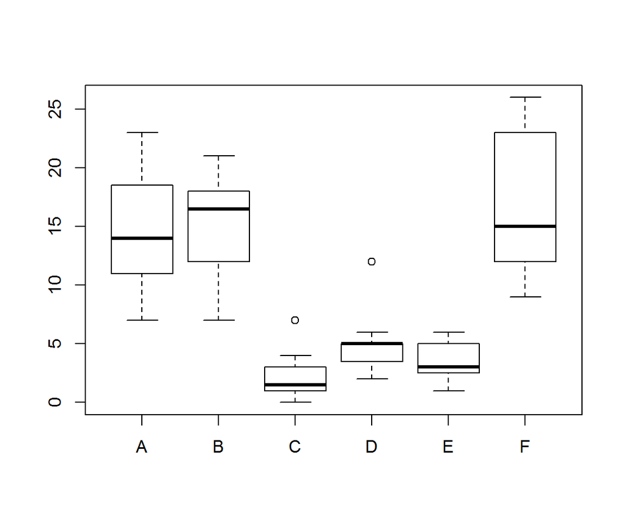

```r
 boxplot(count ~ spray, data=InsectSprays)
```

Aún así realizaremos una ANOVA para ver cual sería el procedimiento. Hay varias maneras de realizar una ANOVA con R.

```r
salida.aov = aov(count ~ spray, data=InsectSprays)
summary(salida.aov)
```

```
##             Df Sum Sq Mean Sq F value Pr(>F)
## spray        5   2669   533.8    34.7 <2e-16 ***
## Residuals   66   1015    15.4
## ---
## Signif. codes:  0 '***' 0.001 '**' 0.01 '*' 0.05 '.' 0.1 ' ' 1
```

Otra manera es utilizar la orden `oneway.test()` que hace la corrección de Welch para varianzas distintas (pero requiere normalidad)

```r
oneway.test(count~spray,data=InsectSprays)
```

```
##
##  One-way analysis of means (not assuming equal variances)
##
## data:  count and spray
## F = 36.065, num df = 5.000, denom df = 30.043, p-value = 7.999e-12
```

El resultado difiere del anterior por la corrección de Welch. Si ponemos la opción `var.equal=TRUE` obtendremos los mismos resultados que con `aov`

```r
oneway.test(count~spray,data=InsectSprays, var.equal=TRUE)
```

```
##
##  One-way analysis of means
##
## data:  count and spray
## F = 34.702, num df = 5, denom df = 66, p-value < 2.2e-16
```

```r
modelo=lm(count~spray,data=InsectSprays)
anova(modelo)
```

```
## Analysis of Variance Table
##
## Response: count
##           Df Sum Sq Mean Sq F value    Pr(>F)
## spray      5 2668.8  533.77  34.702 < 2.2e-16 ***
## Residuals 66 1015.2   15.38
## ---
## Signif. codes:  0 '***' 0.001 '**' 0.01 '*' 0.05 '.' 0.1 ' ' 1
```

### 7.2 Test Post-Hoc

Si queremos ahora ver que grupos son significativamente distintos, podemos hacer un test Post Hoc. Se pueden hacer estos tests con el comando `pairwise.t.test(variable,grupo)`. Este método nos permite hacer distintas correcciones con `p.adjust=` Por ejemplo para realizar la corrección de Bonferroni realizaríamos:

```r
with(InsectSprays,pairwise.t.test(count,spray,p.adj="bonferroni"))
```

```
##
##  Pairwise comparisons using t tests with pooled SD
##
## data:  count and spray
##
##   A       B       C       D       E
## B 1       -       -       -       -
## C 1.1e-09 1.3e-10 -       -       -
## D 1.5e-06 1.8e-07 1       -       -
## E 4.1e-08 4.9e-09 1       1       -
## F 1       1       4.2e-12 6.1e-09 1.6e-10
##
## P value adjustment method: bonferroni
```

En R el test HSD de Tuckey (Honest Significant Difference) que nos da intervalos de confianza corregidos par las diferencias de medias para cada par de grupos.

```r
TukeyHSD(salida.aov)
```

```
##   Tukey multiple comparisons of means
##     95% family-wise confidence level
##
## Fit: aov(formula = count ~ spray, data = InsectSprays)
##
## $spray
##            diff        lwr       upr     p adj
## B-A   0.8333333  -3.866075  5.532742 0.9951810
## C-A -12.4166667 -17.116075 -7.717258 0.0000000
## D-A  -9.5833333 -14.282742 -4.883925 0.0000014
## E-A -11.0000000 -15.699409 -6.300591 0.0000000
## F-A   2.1666667  -2.532742  6.866075 0.7542147
## C-B -13.2500000 -17.949409 -8.550591 0.0000000
## D-B -10.4166667 -15.116075 -5.717258 0.0000002
## E-B -11.8333333 -16.532742 -7.133925 0.0000000
## F-B   1.3333333  -3.366075  6.032742 0.9603075
## D-C   2.8333333  -1.866075  7.532742 0.4920707
## E-C   1.4166667  -3.282742  6.116075 0.9488669
## F-C  14.5833333   9.883925 19.282742 0.0000000
## E-D  -1.4166667  -6.116075  3.282742 0.9488669
## F-D  11.7500000   7.050591 16.449409 0.0000000
## F-E  13.1666667   8.467258 17.866075 0.0000000
```

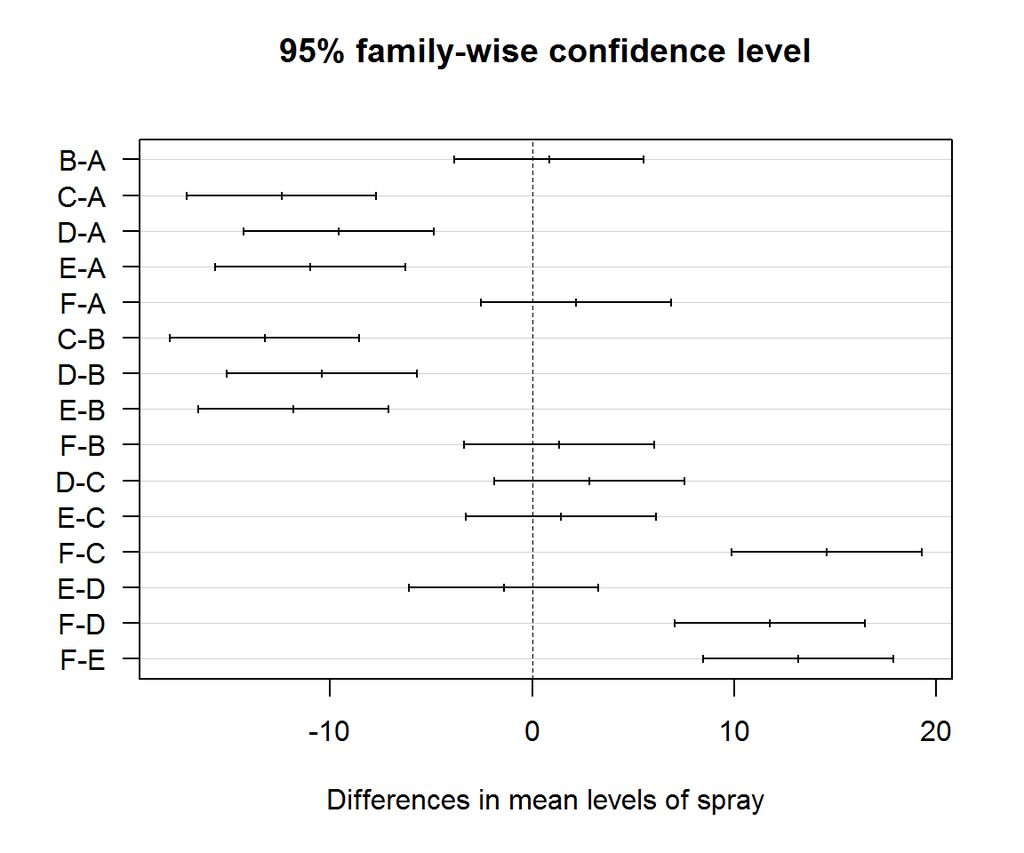

```r
plot(TukeyHSD(salida.aov),las=1)
```

`las` nos dice como son las etiquetas de las con respecto a los ejes puede tomar los valores: 0=paralelas, 1=todas horizontales, 2=todas perpendiculares a los ejes, 3=todas verticales)

Podemos obtener tambien información examinando el modelo lineal

```r
summary(modelo)
```

```
##
## Call:
## lm(formula = count ~ spray, data = InsectSprays)
##
## Residuals:
##    Min     1Q Median     3Q    Max
## -8.333 -1.958 -0.500  1.667  9.333
##
## Coefficients:
##             Estimate Std. Error t value Pr(>|t|)
## (Intercept)  14.5000     1.1322  12.807  < 2e-16 ***
## sprayB        0.8333     1.6011   0.520    0.604
## sprayC      -12.4167     1.6011  -7.755 7.27e-11 ***
## sprayD       -9.5833     1.6011  -5.985 9.82e-08 ***
## sprayE      -11.0000     1.6011  -6.870 2.75e-09 ***
## sprayF        2.1667     1.6011   1.353    0.181
## ---
## Signif. codes:  0 '***' 0.001 '**' 0.01 '*' 0.05 '.' 0.1 ' ' 1
##
## Residual standard error: 3.922 on 66 degrees of freedom
## Multiple R-squared:  0.7244, Adjusted R-squared:  0.7036
## F-statistic:  34.7 on 5 and 66 DF,  p-value: < 2.2e-16
```

Otros métodos para comparaciones múltiples se pueden encontrar en el paquete `multcomp`.

### 7.3 Verificando las condiciones

Una manera formal de probar si las varianzas son iguales es el test de Bartlett.

```r
bartlett.test(count ~ spray, data=InsectSprays)
```

```
##
##  Bartlett test of homogeneity of variances
##
## data:  count by spray
## Bartlett's K-squared = 25.96, df = 5, p-value = 9.085e-05
```

No podemos asegurar que las varianzas son iguales.

Podemos obtener una serie de diagnósticos de un test de anova con `plot(salida.aov)`

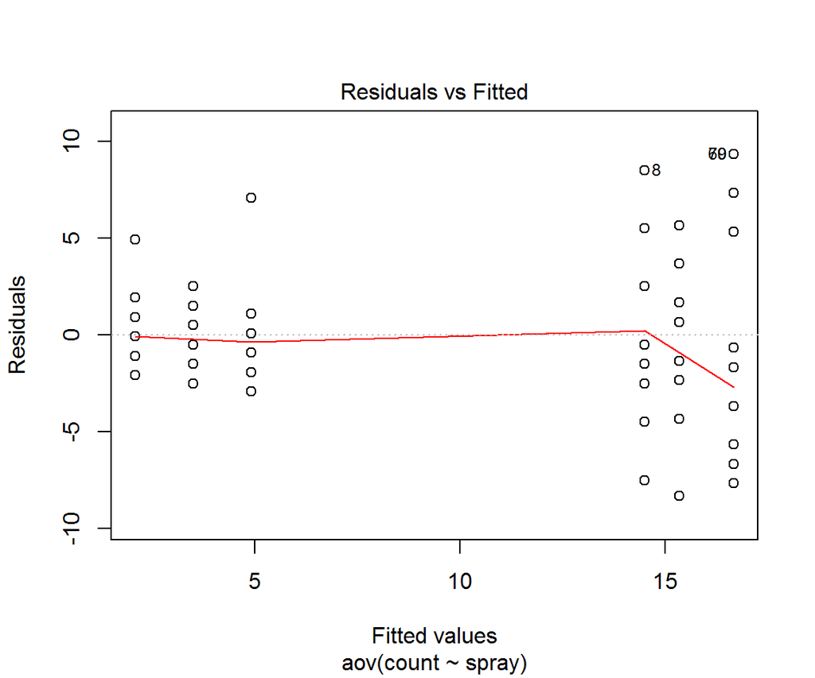

```r
plot(salida.aov,1)
```

Nos da un gráfico de la distribución de los residuos. Idealmente ha de mostrar la misma dispersión en cada valor. Aquí se aprecia un preocupante aumento en la dispersión de los residuos para valores grandes.

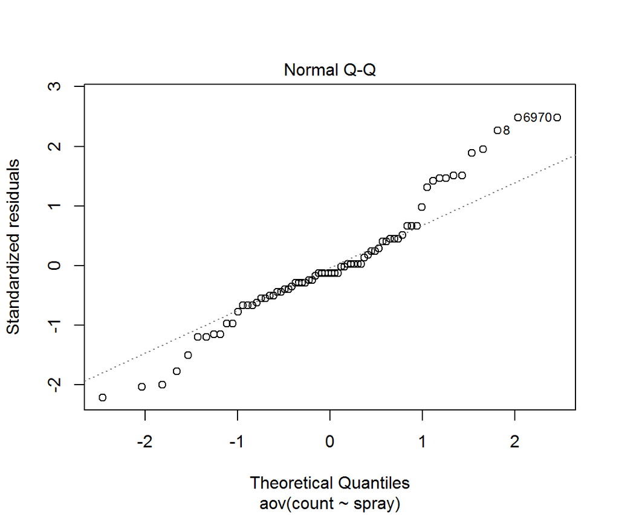

```r
plot(salida.aov,2)
```

Nos da un gráfico cuantil-cuantil que compara la distribución de los residuos con una normal. Vemos que en las colas se aleja de una normal.

### 7.4 Alternativa no paramétrica. Test de Kruskal-Wallis.

La alternativa no paramétrica es el test de Kruskall-Wallis. Este test necesita que todas las distribuciones sean similares y que haya homogeneidad de varianzas.

```r
kruskal.test(count ~ spray, data=InsectSprays)
```

```
##
##  Kruskal-Wallis rank sum test
##
## data:  count by spray
## Kruskal-Wallis chi-squared = 54.691, df = 5, p-value = 1.511e-10
```

### 7.5 Transformaciones de los datos

Cuando nuestros datos no cumplen las condiciones para un test (normalidad, igualdad de varianzas), podemos aplicar transformaciones a nuestros datos $Y'=f(Y)$ para que si las cumplan y realizar los tests sobre los datos transformados. Habrá que tener especial cuidado a la hora de interpretar los resultados pues nos interesan resultados sobre los datos sin transformar.

Las transformaciones más habituales son:

- $Y'=\log(Y)$ Transformación válida para valores positivos o $Y'=\log(Y+1)$ si los datos incluyen al 0. La media aritmética queda transformada en media geométrica. Algunos casos en los que esta transformación es útil comprenden cuando las medidas son cocientes o productos de variables o cuando la distribución de los datos tiene una cola a la derecha o cuando el grupo que tiene la media mayor también tiene la desviación estandar mayor o cuando los datos comprenden varios ordenes de magnitud.
- $Y'=\arcsin(Y)$ Usada fundamentalmente para proporciones.
- $Y'=\sqrt{Y+a}$ donde $a$ puede tomar los valores 0, 1/2 o 1 según los datos. Usada cuando los datos son conteos.

Hay muchas otras transformaciones posibles, pero hay que tener cuidado a la hora de probar distintas transformaciones porque podríamos incurrir en los mismos problemas que al hacer comparaciones múltiples (Incremento del error de tipo I)

En los datos de InsectSpray si hacemos:

```r
bartlett.test(sqrt(count) ~ spray, data=InsectSprays)
```

```
##
##  Bartlett test of homogeneity of variances
##
## data:  sqrt(count) by spray
## Bartlett's K-squared = 3.7525, df = 5, p-value = 0.5856
```

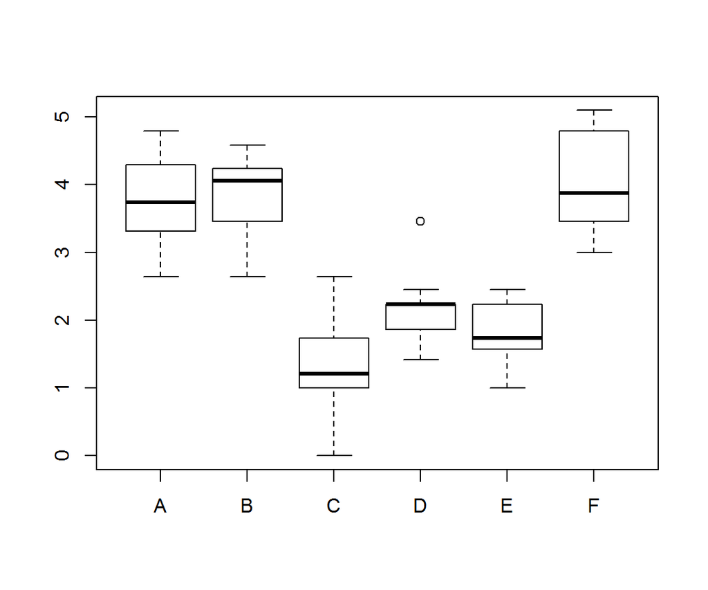

```r
with(InsectSprays,boxplot(sqrt(count) ~ spray))
```

```r
salida.aov2 <- aov(sqrt(count) ~ spray, data = InsectSprays)
summary(salida.aov2)
```

```
##             Df Sum Sq Mean Sq F value Pr(>F)
## spray        5  88.44  17.688    44.8 <2e-16 ***
## Residuals   66  26.06   0.395
## ---
## Signif. codes:  0 '***' 0.001 '**' 0.01 '*' 0.05 '.' 0.1 ' ' 1
```

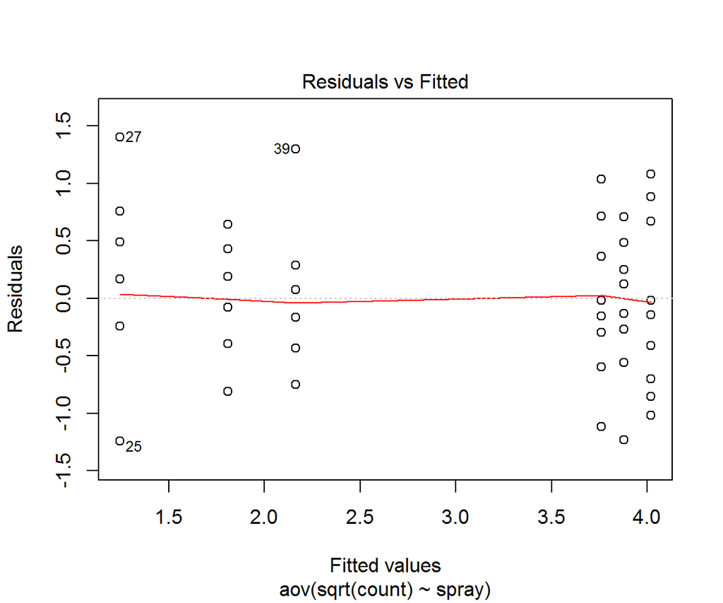

```r
plot(salida.aov2,1)
```

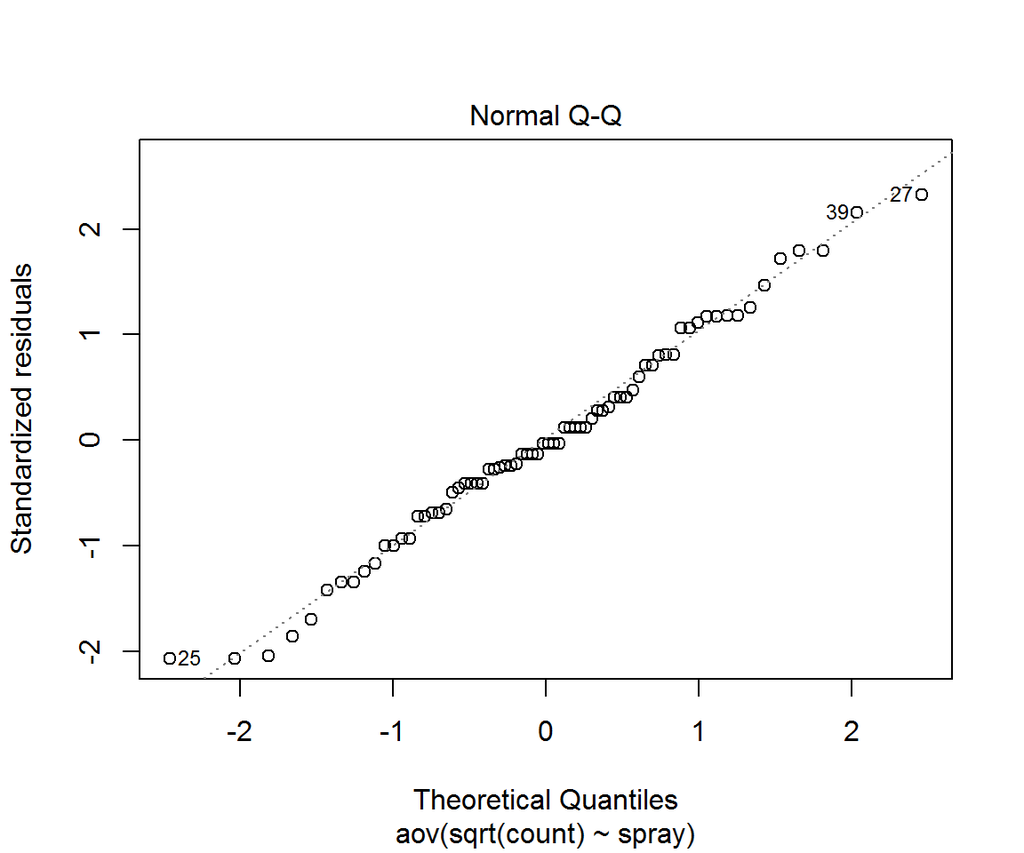

```r
plot(salida.aov2,2)
```

### 7.6 Anova de dos vías.

En el fichero *quinn.csv* encontramos datos sobre los efectos que tienen la estación del año y la densidad de ejemplares adultos en la producción de huevos de la especie *Sinphonaria Diemenensis*

```r
quinn=read.csv("quinn.csv")
str(quinn)
```

```
## 'data.frame':    24 obs. of  3 variables:
##  $ DENSITY: int  8 8 8 8 8 8 15 15 15 15 ...
##  $ SEASON : Factor w/ 2 levels "spring","summer": 1 1 1 2 2 2 1 1 1 2 ...
##  $ EGGS   : num  2.88 2.62 1.75 2.12 1.5 ...
```

Este conjunto de datos es típico de un ANOVA con dos factores (y efectos fijos). Tenemos una variable (respuesta) cuantitativa, que es la producción de huevos (la tercera columna de los datos). Y queremos estudiar la relación de esa variable con dos variables (explicativas), que son la la densidad de adultos y la estación (primera y segunda columnas, respectivamente).

Se trata de dos variables cualitativas o factores. Esto es especialmente evidente en el caso de la variable SEASON, que tiene dos niveles (spring y summer). Vemos que la variable DENSITY no es un factor, así que la transformamos en uno.

```r
quinn$DENSITY = factor(quinn$DENSITY)
str(quinn)
```

```
## 'data.frame':    24 obs. of  3 variables:
##  $ DENSITY: Factor w/ 4 levels "8","15","30",..: 1 1 1 1 1 1 2 2 2 2 ...
##  $ SEASON : Factor w/ 2 levels "spring","summer": 1 1 1 2 2 2 1 1 1 2 ...
##  $ EGGS   : num  2.88 2.62 1.75 2.12 1.5 ...
```

```r
quinn.aov = aov(EGGS ~ SEASON + DENSITY, data = quinn)
summary(quinn.aov)
```

```
##             Df Sum Sq Mean Sq F value   Pr(>F)
## SEASON       1  3.250   3.250   20.05 0.000258 ***
## DENSITY      3  5.284   1.761   10.87 0.000223 ***
## Residuals   19  3.079   0.162
## ---
## Signif. codes:  0 '***' 0.001 '**' 0.01 '*' 0.05 '.' 0.1 ' ' 1
```

```r
anova(quinn.aov)
```

```
## Analysis of Variance Table
##
## Response: EGGS
##           Df Sum Sq Mean Sq F value    Pr(>F)
## SEASON     1 3.2502  3.2502  20.054 0.0002576 ***
## DENSITY    3 5.2841  1.7614  10.868 0.0002226 ***
## Residuals 19 3.0793  0.1621
## ---
## Signif. codes:  0 '***' 0.001 '**' 0.01 '*' 0.05 '.' 0.1 ' ' 1
```

Podemos hacer un estudio factorial (viendo las posibles interacciones)

```r
quinn.aov = aov(EGGS ~ SEASON * DENSITY, data = quinn)
summary(quinn.aov)
```

```
##                Df Sum Sq Mean Sq F value   Pr(>F)
## SEASON          1  3.250   3.250  17.842 0.000645 ***
## DENSITY         3  5.284   1.761   9.669 0.000704 ***
## SEASON:DENSITY  3  0.165   0.055   0.301 0.823955
## Residuals      16  2.915   0.182
## ---
## Signif. codes:  0 '***' 0.001 '**' 0.01 '*' 0.05 '.' 0.1 ' ' 1
```

```r
anova(quinn.aov)
```

```
## Analysis of Variance Table
##
## Response: EGGS
##                Df Sum Sq Mean Sq F value    Pr(>F)
## SEASON          1 3.2502  3.2502 17.8419 0.0006453 ***
## DENSITY         3 5.2841  1.7614  9.6691 0.0007041 ***
## SEASON:DENSITY  3 0.1647  0.0549  0.3014 0.8239545
## Residuals      16 2.9146  0.1822
## ---
## Signif. codes:  0 '***' 0.001 '**' 0.01 '*' 0.05 '.' 0.1 ' ' 1
```

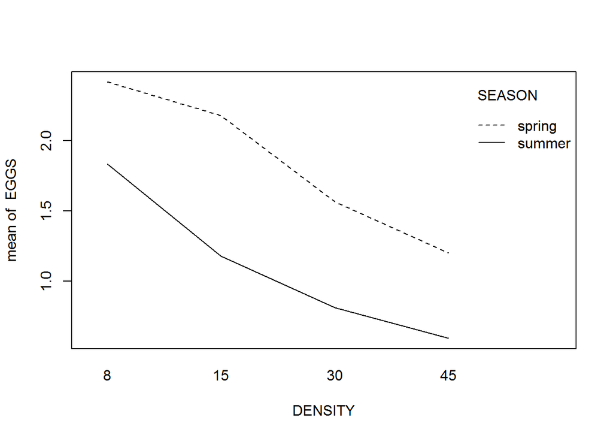

```r
with(quinn,interaction.plot(DENSITY, SEASON, EGGS))
```

El factor DENSITY se muestra en el eje horizontal, la respuesta EGGS en el eje vertical, y cada uno de los dos factores de SEASON se muestra como una línea que conecta los correspondientes valores. En un caso ideal, la ausencia completa de interacción correspondería a dos líneas perfectamente paralelas en este gráfico (y la existencia de interacción es evidente cuando las líneas se cruzan). En la práctica, el paralelismo en general está lejos de ser perfecto. No obstante, la gráfica de este ejemplo sí parece indicar que no existe interacción entre ambos factores. Y en cualquier caso, tenemos los resultados de la tabla ANOVA para corroborarlo.

## Ejercicios

### Ejercicio 1

Mediante la estimación del intervalo de confianza de la media de los datos muestreados de *colesterol.txt* (al 95% de nivel de confianza) conteste la siguiente pregunta.

Siendo que los datos muestreados en este archivo pertenecen a 40 personas que toman un medicamento para disminuir el colesterol y que la media de nivel de colesterol antes de someterse a la prueba era de 240, ¿podemos concluir que ha sido eficaz el tratamiento?

Nota: para leer los datos tener en cuenta que `read.table` crea un dataframe aunque solo tengamos una variable y en este caso tenemos que sacar la variable *colesterol* fuera. Esto lo conseguimos con los siguientes pasos.

```r
aux=read.table("colesterol.txt",header=TRUE)
colesterol = aux$colesterol
```

### Ejercicio 2

Se ha medido la concentración de lípidos en muestras de sangre de 60 estudiantes, obteniéndose los siguientes resultados en mg/100ml contenidos en el fichero *lipidos.csv*

```r
aux=read.table("lipidos.csv",header=TRUE)
lipidos = aux$Lipidos
```

1. Dibujar el correspondiente histograma y diagrama de caja.
2. Calcular la media, la desviación standard y los cuartiles.
3. Siendo que el valor medio para personas sanas que tienen una dieta adecuada (baja en contenido graso) es de 50 mg/100ml; ¿puede Ud. asegurar que la dieta normal que consume la población de estudiantes universitarios está de acuerdo a dicho valor? Informe el resultado con nivel de confianza del 95%.

### Ejercicio 3

Una hipótesis común en la investigación médica es que la vitamina C previene el catarro. Organizamos un estudio para contrastar esta hipótesis utilizando a 20 individuos. A 10 de ellos se les da Vitamina C y a otros 10 un placebo en forma de pastillas. Se recoje el número de catarros en un periodo de 12 meses en el archivo *ncatarros.txt*

Comparar los datos gráficamente utilizando gráficos de cajas. Realizar un intervalo de confianza al 95% de confianza para la diferencia de las medias ¿Crees que hay evidencia a favor de la hipótesis?

### Ejercicio 4

En una clínica pediátrica se hace un estudio para saber lo efectiva que es la aspirina en reducir la temperatura corporal. Se les toma la temperatura a 12 niños de 5 años aquejados de la gripe justo antes y exactamente una hora después de tomar aspirinas. Asumimos que las distribuciones son normales y queremos comprobar la hipótesis de que la aspirina está reduciendo la temperatura. Encontraras los datos en el archivo *aspirina.txt*

Calcular la media y desviación típica de la diferencia de las temperaturas. Construir un intervalo de confianza al 95% para la diferencia de temperaturas ¿Es efectivo tomar la aspirina?

### Ejercicio 5

Se realiza un estudio para establecer una ecuación mediante la cual se pueda utilizar la concentración de estrona en la saliva ( en pg/mL)., para predecir la concentración del esteroide en plasma libre (en pg/mL). Se extrajeron datos de 14 varones sanos almacenados en el archivo *estrona.csv*

1. Dibujar la nube de puntos y la recta de regresión.
2. Hallar los coeficientes de la recta de regresión. Escribir la ecuación de la recta.
3. Utilizar la recta de regresión estimada para predecir el nivel de estrona en plasma libre de un varón cuyo nivel de estrona en saliva es de 17.5 pg/mL.

### Ejercicio 6

En el archivo *riesgo_cardiaco.csv* encontramos da la edad y tensión arterial sistólica de 12 mujeres.

1. Hallar el coeficiente de correlación entre la Edad y la tensión arterial sistólica.
2. Determinar la ecuación de la recta de regresión tomando la Edad como variable independiente.
3. Utilizar la línea estimada para predecir la tensión arterial sistólica de una mujer de 45 años.
4. Estimar la edad de una persona con tensión arterial sistólica 135. Pista: No vale despejar.

### Ejercicio 7

Considerar las siguientes observaciones sobre las variables aleatorias X e Y.

| x | y |
| --- | --- |
| 2.0 | 4.0 |
| 2.1 | 4.4 |
| 2.5 | 6.3 |
| 3.0 | 9.0 |
| 3.5 | 6.2 |
| 3.9 | 4.3 |
| 4.0 | 4.0 |

1. Dibujar la nube de puntos
2. Basándote en el gráfico de a) ¿piensas que el coeficiente de correlación estará cerca de -1, cerca de 0 ó cerca de 1?
3. Calcular el coeficiente de correlación ¿qué tipo de correlación lineal existe entre ambas variables?
4. Determinar los coeficientes de la curva de regresión cuadrática, dibujarla y calcular $R^2$

### Ejercicio 8

Vamos a comparar el peso en seco de plantas obtenido en una plantación dividida en parcelas a las que se han asignado tres condiciones de crecimiento distintas (un control, que puede ser la que se ha empleado hasta ahora y dos “tratamientos” nuevos que queremos comparar. Usaremos los datos presentes en el dataframe `PlantGrowth` cargado por defecto en R. Este tiene dos variables `weight` que nos da el peso en seco de las plantas, y `group` que especifica el tratamientos (con los valores posibles ctrl, trt1 y trt2)

```r
data(PlantGrowth)
str(PlantGrowth)
```

```
## 'data.frame':    30 obs. of  2 variables:
##  $ weight: num  4.17 5.58 5.18 6.11 4.5 4.61 5.17 4.53 5.33 5.14 ...
##  $ group : Factor w/ 3 levels "ctrl","trt1",..: 1 1 1 1 1 1 1 1 1 1 ...
```

- Calcular la media (del peso), deviación estandar (del peso) y tamaño de cada uno de los tres grupos
- Hacer un gráfico con diagramas de cajas de peso para los tres tratamientos (el control y los dos nuevos)
- Comprobar si podemos considerar las varianzas son homogéneas en los tres grupos (usar el test de Bartlett)
- Realizar una ANOVA para contrastar si alguna de las medias son distintas. En el caso de que la respuesta sea afirmativa, realizar un test Post-Hoc adecuado.¿Qué conclusión obtenemos?
- Evaluar la validez de la ANOVA realizando algunos diagramas diagnósticos y comentando los resultados.
- Realizar el mismo estudio con un modelo lineal.